# AnimalsProject

Dominic Ventura and Jamie Hobbs

11/24/2020

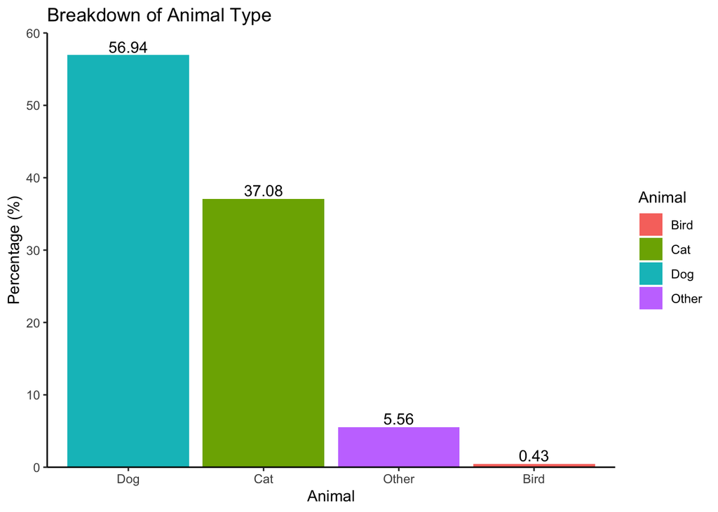

Since cats and dogs made up about 95% of all animals, we decided to only use cats and dogs for this project.

### Collapsing Factors

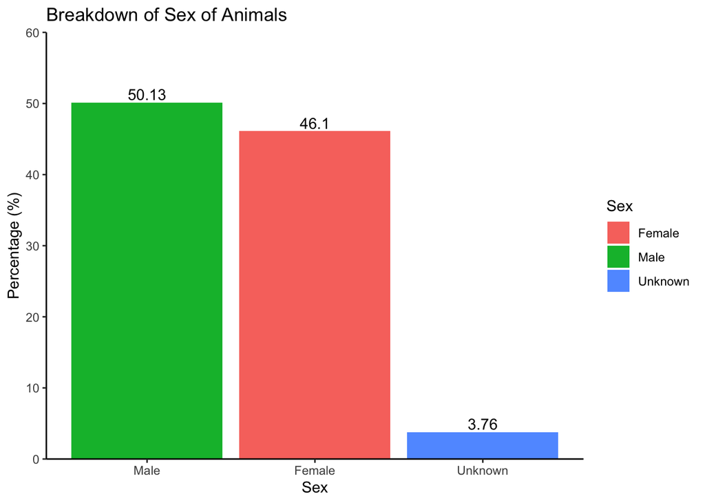

```
## # A tibble: 3 x 3
##   intakereason        n  prop
##   <chr>           <int> <dbl>
## 1 Stray           55199 73.7
## 2 Owner Surrender 14690 19.6
## 3 Other            5015  6.70
```

The intake reasons were condensed into 3 main reasons, the top 2 being surrender by owner and the animal being a stray with everything else condensed into the “other” category.

### Formulation without Interaction

Our response variable for the multinomial regression will be the intake reason for an animals and the predictors will be the animal’s breed, sex, and age.

$$\begin{cases} Y_i \sim_{i.i.d} Multinomial(p_{i,1}, \ p_{i,2}, \ p_{i,3}), \ where \ Y_i = Intake \ Reason \\ \\ log(\frac{p_{ij}} {p_{i3}}) = \beta_0 + \beta_1 \cdot Breed_{Dog,i} + \beta_2 \cdot Sex_{Male,i} + \beta_3 \cdot Sex_{Unknown,i} + \beta_4 \cdot Age_i\ , \ i =1,...,n \\ \\ p_{i3} = 1 - \sum_{\ell=1}^2 \ p_{i\ell} = 1 - (p_{i1} + p_{i2}) \end{cases}$$

### Formulation with Interaction

$$\begin{cases} Y_i \sim_{i.i.d} Multinomial(p_{i,1}, \ p_{i,2}, \ p_{i,3}), \ where \ Y_i = Intake \ Reason \\ \\ log(\frac{p_{ij}}{p_{i3}}) = \beta_0 + \beta_1 \cdot Breed_{Dog,i} + \beta_2 \cdot Sex_{Male,i} + \beta_3 \cdot Sex_{Unknown,i} \ + \\ \beta_4 \cdot Age_i\ + \beta_5 (Breed_{Dog,i} \times Age_i), \ i = 1,...,n \\ \\ p_{i3} = 1 - \sum_{\ell=1}^2 \ p_{i\ell} = 1 - (p_{i1} + p_{i2}) \end{cases}$$

### Multinomial Regression

Our primary interest is seeing if we can use an animal’s breed, sex, and age to predict their intake reason at the shelter.

```
## Call:
## multinom(formula = intakereason ~ animal_type + sex + age2, data = animals)
##
## Coefficients:
##                 (Intercept) animal_typeDog    sexMale sexUnknown
## Owner Surrender    2.386547      -1.288334 -0.3355893 -1.5747965
## Stray              3.738442      -1.206729 -0.2078056  0.6229818
##                        age2
## Owner Surrender -0.05091225
## Stray           -0.13247191
##
## Std. Errors:
##                 (Intercept) animal_typeDog    sexMale sexUnknown
## Owner Surrender  0.04512646     0.04433419 0.03353939  0.1883605
## Stray            0.04311359     0.04194812 0.03062025  0.1529062
##                        age2
## Owner Surrender 0.004433625
## Stray           0.004090889
##
## Residual Deviance: 104747.8
## AIC: 104767.8
```

### Surrendered by Owner

Age: Per 1 year increase in age, the odds of the intake reason being that the animal was surrendered by the owner as opposed to being one of the “other” reasons multiply by $e^{-0.05}$, holding all else constant.

Dog: The odds a dog is taken in because their owner wanted to get rid of them as opposed to “other” reasons are $e^{-1.29}$ times that of a cat, holding all else constant.

Sex (Male): The odds a male cat or dog is taken in because their owner wanted to get rid of them as opposed to “other” reasons multiply by $e^{-0.34}$ times that of a female cat or dog, holding all else constant.

Sex (Unknown): The odds a cat or dog with unknown sex is taken in because their owner wanted to get rid of them as opposed to “other” reasons multiply by $e^{-1.57}$ times that of a female cat or dog, holding all else constant.

### Stray

Age: Per 1 year increase in age, the odds of the intake reason being that the animal was a stray as opposed to being one of the “other” reasons multiply by $e^{-0.13}$, holding all else constant.

Dog: The odds of a dog being taken in because it was a stray as opposed to being one of the “other” reasons are $e^{-1.21}$ times that of a cat, holding all else constant.

### Summary of the fit

```r
summary(fit)
```

```
## Call:
## multinom(formula = intakereason ~ animal_type + sex + age2 +
##     animal_type:age2, data = animals)
##
## Coefficients:
##                 (Intercept) animal_typeDog    sexMale sexUnknown
## Owner Surrender    2.415650      -1.233784 -0.3374630  -1.566566
## Stray              3.947634      -1.495705 -0.2152607   0.557607
##                        age2 animal_typeDog:age2
## Owner Surrender -0.04752861         -0.03421362
## Stray           -0.23071634          0.12691753
##
## Std. Errors:
##                 (Intercept) animal_typeDog    sexMale sexUnknown
## Owner Surrender  0.05270407     0.05569824 0.03358588  0.1894767
## Stray            0.05062729     0.05273596 0.03060424  0.1544330
##                        age2 animal_typeDog:age2
## Owner Surrender 0.008748101          0.01024375
## Stray           0.009041408          0.01010424
##
## Residual Deviance: 104064.2
## AIC: 104088.2
```

### Confidence Intervals

```r
round(confint(fit),3)
```

```
## , , Owner Surrender
##
##                      2.5 % 97.5 %
## (Intercept)          2.312  2.519
## animal_typeDog      -1.343 -1.125
## sexMale             -0.403 -0.272
## sexUnknown          -1.938 -1.195
## age2                -0.065 -0.030
## animal_typeDog:age2 -0.054 -0.014
##
## , , Stray
##
##                      2.5 % 97.5 %
## (Intercept)          3.848  4.047
## animal_typeDog      -1.599 -1.392
## sexMale             -0.275 -0.155
## sexUnknown           0.255  0.860
## age2                -0.248 -0.213
## animal_typeDog:age2  0.107  0.147
```

Interpretation of a CI for animal surrendered by owner:

Male: We are 95% confident that the odds that a male cat or dog is taken in because their owner wanted to get rid of them as opposed to one of the “other” reasons multiply by between ($e^{-0.403}$, $e^{-0.272}$), holding all else constant.

$$log(\frac{ \hat{p_{Surrender}} } {\hat{ p_{Other}} }) = 2.42 - 1.23 \cdot Breed_{Dog} - 0.34 \cdot Sex_{Male} - 1.57 \cdot Sex_{Unknown} - 0.05 \cdot Age\ \\ - 0.03 (Breed_{Dog} \times Age) \\
log(\frac{ \hat{p_{Stray}} } {\hat{ p_{Other}} }) = 3.95 - 1.5 \cdot Breed_{Dog} - 0.22 \cdot Sex_{Male} + 0.56 \cdot Sex_{Unknown} - 0.23 \cdot Age\ \\ + 0.12 (Breed_{Dog} \times Age)$$

### Interpretations (with interaction term)

## Surrendered by Owner

Dog: The odds a dog is taken in because their owner surrendered them as opposed to “other” reasons are $e^{-1.23-0.03 \cdot Age}$ times that of a cat, holding all else constant.

Sex (Male): The odds a male cat or dog is taken in because their owner wanted to get rid of them as opposed to “other” reasons multiply by $e^{-0.34}$ times that of a female cat or dog, holding all else constant.

Sex (Unknown): The odds a cat or dog with unknown sex is taken in because their owner wanted to get rid of them as opposed to “other” reasons multiply by $e^{-1.57}$ times that of a female cat or dog, holding all else constant.

### Stray

Dog: The odds of a dog being taken in because it was a stray as opposed to being one of the “other” reasons are $e^{-1.5+0.12 \cdot Age}$ times that of a cat, holding all else constant.

### Testing each predictor as a whole

To test each predictor as a whole, we perform the Likelihood Ratio Test.

```r
Anova(fit)
```

```
## Analysis of Deviance Table (Type II tests)
##
## Response: intakereason
##                  LR Chisq Df Pr(>Chisq)
## animal_type       1106.98  2  < 2.2e-16 ***
## sex                739.55  4  < 2.2e-16 ***
## age2              1390.21  2  < 2.2e-16 ***
## animal_type:age2   683.57  2  < 2.2e-16 ***
## ---
## Signif. codes:  0 '***' 0.001 '**' 0.01 '*' 0.05 '.' 0.1 ' ' 1
```

```r
# z scores
z <- round(summary(fit)$coefficients / summary(fit)$standard.errors,3)

# p values
p <- (1 - pnorm(abs(z), 0, 1)) * 2
#p
```

We can see that all of the predictors are statistically significant.

### Significance of overall model

```
## Likelihood ratio tests of Multinomial Models
##
## Response: intakereason
##                                         Model Resid. df Resid. Dev   Test
## 1                                           1    149806   108680.4
## 2 animal_type + sex + age2 + animal_type:age2    149796   104064.2 1 vs 2
##      Df LR stat. Pr(Chi)
## 1
## 2    10 4616.211       0
```

A very large LRT stat indicates strong evidence against $H_0: \{All \ \beta_{ij}'s = 0 \} vs. H_a: \{At \ least \ one \ \beta_{ij} \ \not = 0 \}$

### Confusion Matrix of Predicted Reasons

```r
table(predicted_class, test$intakereason)
```

```
##
## predicted_class   Other Owner Surrender Stray
##   Other               0               0     1
##   Owner Surrender    21             146   157
##   Stray            1471            4250 16426
```

### Misclassification Rate

```r
mean(as.character(predicted_class) != as.character(test$intakereason)) * 100
```

```
## [1] 26.25489
```

Predictions were misclassified roughly 26% of the time.

### Effect Display

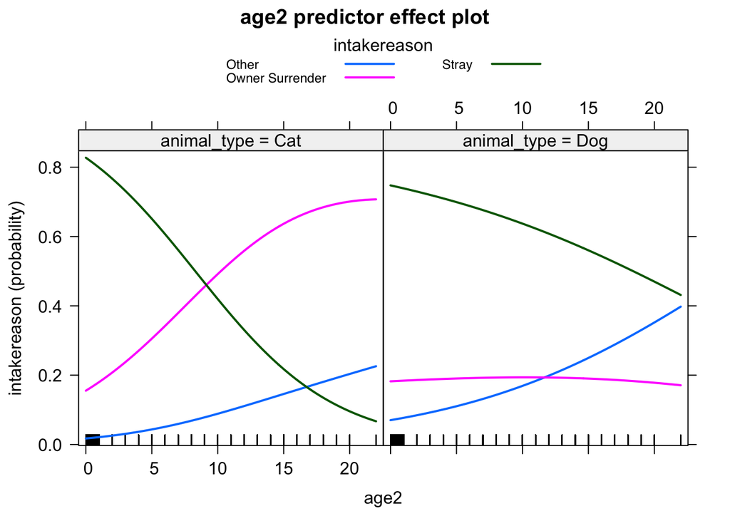

This effect plot plots the probability of an intake reason by age for animal type. We can see that for cats, stray and surrendered by owner are inverses. As a cat gets older, the probability of the intake reason being that it was surrendered by owner increases, while the probability of the intake reason being “stray” decreases as a cat gets older.

### Prediction examples

```
## [1] Stray
## Levels: Other Owner Surrender Stray
```

```
##           Other Owner Surrender           Stray
##            0.43            0.16            0.41
```

```
##           Other Owner Surrender           Stray
##            0.22            0.69            0.09
```

### Time Series

For the time series portion, we are trying to forecast the number of animals brought into the animal shelter a year into the future. We will do this by breaking our data into a train set and a test set and compare at the end.

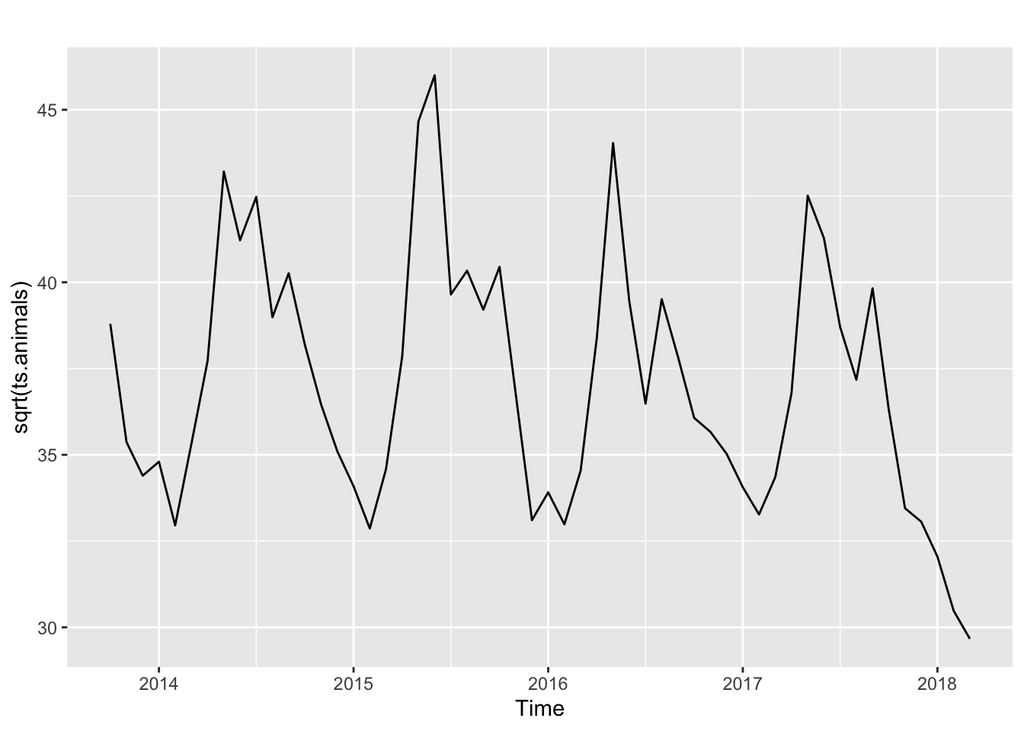

The inital time series plot had some non-constant variance, so a BoxCox transformation was applied in order to reduce some of the non-constant variance.

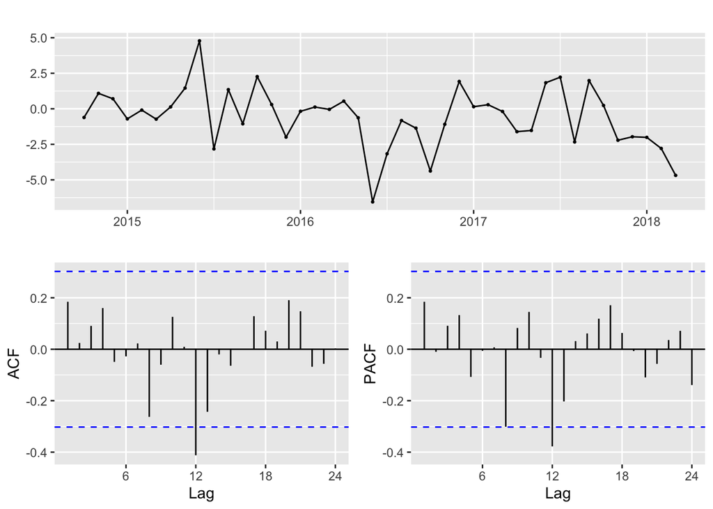

### ARIMA models

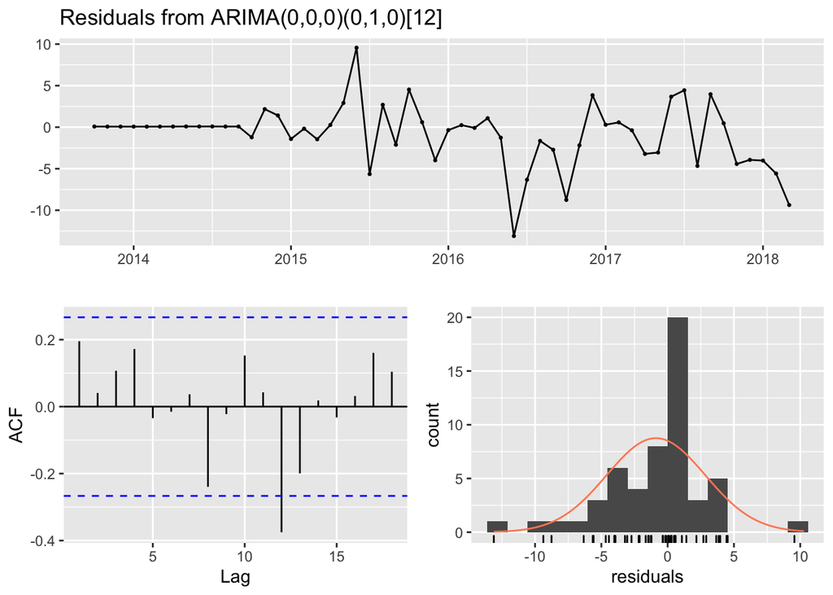

```
##
##  Ljung-Box test
##
## data:  Residuals from ARIMA(0,0,0)(0,1,0)[12]
## Q* = 10.445, df = 11, p-value = 0.4908
##
## Model df: 0.   Total lags used: 11
```

Now we check the residuals of our ARIMA model to see if the fitted residuals are white noise or not. The mean is roughly 0 and the variance is a little shaky but not too bad. From the ACF plot, all the ACFs except one are within the white noise bands, and the residuals are normally distriubted. The Ljung-Box Test has a high p-value of about 0.5, thus we fail to reject the null hypothesis of the residuals being white noise.

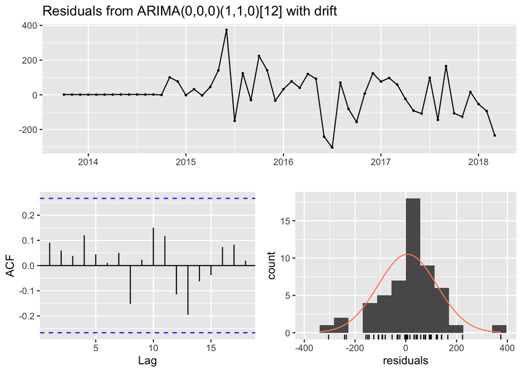

```
##
##  Ljung-Box test
##
## data:  Residuals from ARIMA(0,0,0)(1,1,0)[12] with drift
## Q* = 5.9926, df = 9, p-value = 0.7407
##
## Model df: 2.   Total lags used: 11
```

Then we tried the R function that chooses, what it thinks to be, the best ARIMA model for the given data. Here it chooses the ARIMA(0,0,0)(1,1,0)[12] model. It meets all the same criteria (mean and variance stabilization, ACFs being within the bands, and the residuals being normally distributed) compared to the other model, but the p-value is higher. So we will go with this ARIMA model.

### Forecasting

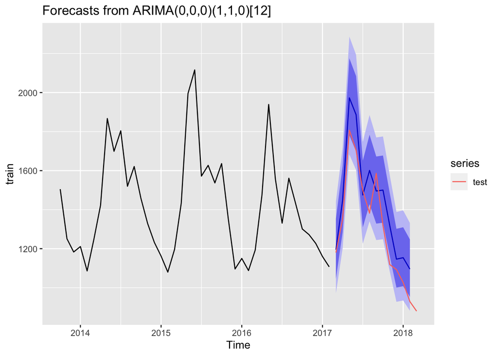

The accuracy of our forecasts are shown below. Even though it says “Training set” it is actually the accuracy of the test set. We will only interpret RMSE and MAPE as an example and also because RMSE is scale dependent and MAPE is not.

RMSE: The forecasted values miss the actual number of intakes by 65.1 intakes, on average.

MAPE: The forecasted values miss the actual number of intakes by 2.2%, on average.

```
##                    ME     RMSE      MAE       MPE     MAPE       MASE
## Training set -15.6429 65.07783 20.42827 -1.870102 2.228894 0.06809423
##                      ACF1
## Training set -0.002628357
```